# PracticalMachineLearning-FinalProject

RMD and html output for the final project

# Final project

## Introduction

In this project, we will use data from accelerometers on the belt, forearm, arm, and dumbell of 6 participants to predict the manner in which they did the exercise. This is the “classe” variable in the training set. I will also use the prediction model to predict 20 different test cases.

## Exploratory Analysis

Load the data. Looking through the data I saw there was some “#DIV/0” that I need to convert to NA

```r
dataIn <- read.csv("C:/Users/Brian/OneDrive/DataScience/PracticalMachineLearning/pml-training.csv", na.strings = c("NA", "#DIV/0!", ""))
test <- read.csv("C:/Users/Brian/OneDrive/DataScience/PracticalMachineLearning/pml-testing.csv", na.strings = c("NA", "#DIV/0!", ""))
```

Look through the data

```r
str(dataIn[1:5,1:20])
```

```
## 'data.frame':    5 obs. of  20 variables:
##  $ X                   : int  1 2 3 4 5
##  $ user_name           : Factor w/ 6 levels "adelmo","carlitos",..: 2 2 2 2 2
##  $ raw_timestamp_part_1: int  1323084231 1323084231 1323084231 1323084232 1323084232
##  $ raw_timestamp_part_2: int  788290 808298 820366 120339 196328
##  $ cvtd_timestamp      : Factor w/ 20 levels "02/12/2011 13:32",..: 9 9 9 9 9
##  $ new_window          : Factor w/ 2 levels "no","yes": 1 1 1 1 1
##  $ num_window          : int  11 11 11 12 12
##  $ roll_belt           : num  1.41 1.41 1.42 1.48 1.48
##  $ pitch_belt          : num  8.07 8.07 8.07 8.05 8.07
##  $ yaw_belt            : num  -94.4 -94.4 -94.4 -94.4 -94.4
##  $ total_accel_belt    : int  3 3 3 3 3
##  $ kurtosis_roll_belt  : num  NA NA NA NA NA
##  $ kurtosis_picth_belt : num  NA NA NA NA NA
##  $ kurtosis_yaw_belt   : logi  NA NA NA NA NA
##  $ skewness_roll_belt  : num  NA NA NA NA NA
##  $ skewness_roll_belt.1: num  NA NA NA NA NA
##  $ skewness_yaw_belt   : logi  NA NA NA NA NA
##  $ max_roll_belt       : num  NA NA NA NA NA
##  $ max_picth_belt      : int  NA NA NA NA NA
##  $ max_yaw_belt        : num  NA NA NA NA NA
```

There are a lot of columns with “NA” so let’s get rid of those

```r
na_cols <- apply(!is.na(dataIn), 2, sum) > (nrow(dataIn)-1)
dataIn <- dataIn[, na_cols]
test <- test[, na_cols]
```

We are not going to care about username, timestamp and other data in the first six columns since this is not information about the motion

```r
dataIn <- dataIn[, -(1:6)]
test <- test[, -(1:6)]
```

```r
idxTrain <- createDataPartition(y=dataIn$classe, p=0.70, list=FALSE);
train <- dataIn[idxTrain,]
val <- dataIn[-idxTrain,]
```

Some of the covariants have no variance (only a single value) and aren’t useful for our modelling. This removes those columns. On my first run through this turned out to be zero so I added the if…then to work around this.

```r
nz_cols <- nearZeroVar(train)
if( length(nz_cols) >0 ){

  train <- train[, -nz_cols]
  val <- val[, -nz_cols]

} else {
  cat("No near zero variance columns")
}
```

```
## No near zero variance columns
```

## Data preprocessing and selection

There are still a lot of covariates here. I found an interesting post where random forests are used to select the most important variables:

http://www.r-bloggers.com/variable-importance-plot-and-variable-selection/

We will use the randomForest package and plot the variable importance of the covariants.

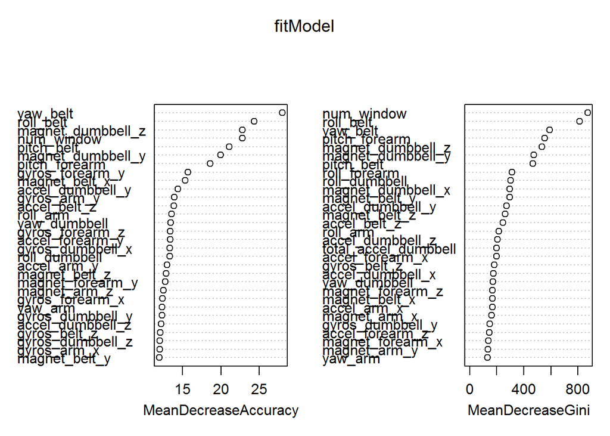

```r
fitModel <- randomForest(classe~., data=train, importance=TRUE, ntree=100)
varImpPlot(fitModel)
```

We will select the top 10 covariates using this code:

```r
rankTable <- varImp(fitModel)
rankTable$total <- rankTable$A+rankTable$B+rankTable$C+rankTable$D+rankTable$E
rankTable <- rankTable[order(-rankTable$total),]
rankRows <- rownames(rankTable[1:10,])
table(rankRows)
```

```
## rankRows
##  accel_dumbbell_y magnet_dumbbell_y magnet_dumbbell_z        num_window
##                 1                 1                 1                 1
##        pitch_belt     pitch_forearm          roll_arm         roll_belt
##                 1                 1                 1                 1
##     roll_dumbbell          yaw_belt
##                 1                 1
```

Although the covariants are important there could still be correlation between them. We will check with the correlation matrix. We’ll set the diagonal elements to zero (these are the self correlated values and are always unity), then pick the largest values. We’ll start with a threshold of 75%.

```r
rankCols <- c(rankRows[1], rankRows[2], rankRows[3], rankRows[4], rankRows[5], rankRows[6], rankRows[7], rankRows[8], rankRows[9], rankRows[10])
corMat <- cor(train[,rankCols])
diag(corMat) <- 0
which(abs(corMat)>0.75, arr.ind=TRUE)
```

```
##           row col
## yaw_belt    3   1
## roll_belt   1   3
```

It looks like both `yaw_belt` and `roll_belt` are strongly correlated. Both of these are also important, but looks like we’ll need to eliminate one or combine using PCA. Since PCA is computationally intensive we will just eliminate one. But which one? We can use a tree classifier to see which one is more important.

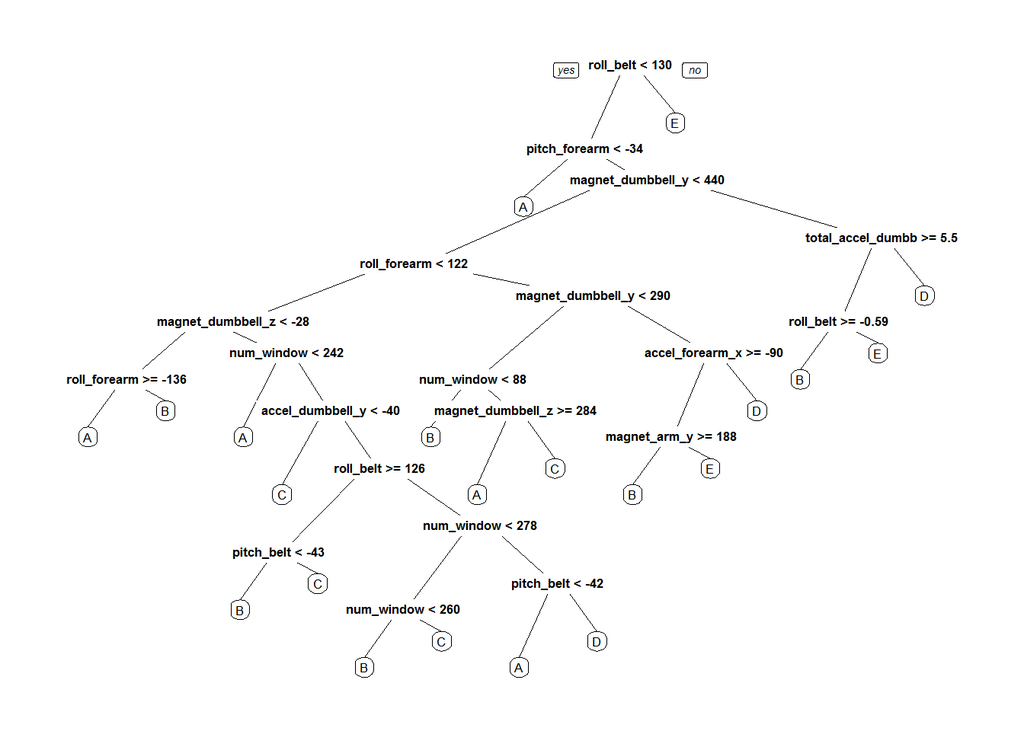

```r
fitModel <- rpart(classe~., data=train, method="class")
prp(fitModel)
```

The variable `roll_belt` comes out on top se we will keep it and eliminate `yaw_belt`

```r
rankCols <- rankCols[-grep("yaw_belt", rankCols)]
```

## Fitting the data

Using the covariates found above we will construct the formula and call the train command from caret. If there is a previous run, just load the data rather than re-running the train command.

```r
set.seed(514159)
strForm <- "classe~"
for (idx in 1:(length(rankCols)-1)){
  strForm <- paste(strForm,rankCols[idx],"+")
}
strForm <- paste(strForm,rankCols[length(rankCols)])

strFinalModelPath = "finalModel.RDS"

if( file.exists(strFinalModelPath)){

  cat("Loading a previous data set")
  finalModel <- readRDS(strFinalModelPath)

} else {

  finalModel <- train(as.formula(strForm), data=train, method ="rf",
                    trControl=trainControl(method="cv",number=2),
                    prox = TRUE,
                    verbose = TRUE,
                    allowParallel = TRUE)

}
```

```
## Loading a previous data set
```

That took a long time calculate. We’ll save off the model so that we can load it rather than calculate it each time

```r
saveRDS(finalModel, strFinalModelPath)
```

With the model built for the training set, we can see how it performs on the validation data set.

```r
results <- predict(finalModel, newdata=val)
confMat <- confusionMatrix(results, val$classe)
confMat
```

```
## Confusion Matrix and Statistics
##
##           Reference
## Prediction    A    B    C    D    E
##          A 1674    1    0    0    0
##          B    0 1137    0    0    2
##          C    0    0 1026    0    0
##          D    0    1    0  964    1
##          E    0    0    0    0 1079
##
## Overall Statistics
##
##                Accuracy : 0.9992
##                  95% CI : (0.998, 0.9997)
##     No Information Rate : 0.2845
##     P-Value [Acc > NIR] : < 2.2e-16
##
##                   Kappa : 0.9989
##  Mcnemar's Test P-Value : NA
##
## Statistics by Class:
##
##                      Class: A Class: B Class: C Class: D Class: E
## Sensitivity            1.0000   0.9982   1.0000   1.0000   0.9972
## Specificity            0.9998   0.9996   1.0000   0.9996   1.0000
## Pos Pred Value         0.9994   0.9982   1.0000   0.9979   1.0000
## Neg Pred Value         1.0000   0.9996   1.0000   1.0000   0.9994
## Prevalence             0.2845   0.1935   0.1743   0.1638   0.1839
## Detection Rate         0.2845   0.1932   0.1743   0.1638   0.1833
## Detection Prevalence   0.2846   0.1935   0.1743   0.1641   0.1833
## Balanced Accuracy      0.9999   0.9989   1.0000   0.9998   0.9986
```

That was a good result, an overall accuracy over 99%. That is probably good enough to try on the 20 question prediction quiz.

## Coursera results

```r
resultsCoursera <- predict(finalModel, newdata = test)
print(resultsCoursera)
```

```
##  [1] B A B A A E D B A A B C B A E E A B B B
## Levels: A B C D E
```

These results scored 100% on the final test. I think the model is pretty good.